# Comparing Means Between Groups

Two at a time please!

P. Lombardo

## Loading packages, etc.

```r
library(tidyverse)
library(patchwork)
# library(DescTools)
library(broom)
fish <- read.csv('data/fish.csv', header = T, stringsAsFactors = T)
```

## Theory

As it turns out, the Central Limit Theorem applies to sampling distributions of some other statistics as well! Two commonly used ones are

1. The difference of sample means from two populations: $\bar x_1 - \bar x_2$.
2. The different of sample percentages from two populations: $\hat p_1 - \hat p_2$.

[**Shiny Visualization!**](https://stem.endicott.edu/pl-shiny/sampling-distributions/difference-in-means-sampdist/)

Again, I’ll spare you the formulas for the standard errors, and we won’t really discuss the potential “tweaks” commonly made after the fact. However, the idea is the same:

> When sample sizes are large enough (in each sample), the sampling distribution for a difference of means (or percentages) for two populations will have a reasonably normal distribution with a formula for the standard error, and the mean equal to the *difference of population means (or percentages)*.

This is great, because if we can say something about how the difference of means behaves, we can compare them. What, don’t believe me!?!

Well, if $\mu_1 - \mu_2$ is positive, then $\mu_1 - \mu_2 >0$, so solving for $\mu_1$ gives:
$$\mu_1 > \mu_2.$$

In fact, all the usual comparisons for two groups parameters (means or percentages) can be reduced to a statement of how *the difference of the parameters* compares against zero. It is useful to be able to toggle between these two equivalent viewpoints easily, so … well… practice it!

## The `ToothGrowth` data set

The `ToothGrowth` data set comes from an experiment looking to explore the effect of vitamin C on the tooth growth of Guinea pigs. Let’s explore a little.

```r
#place code here
?ToothGrowth
```

### A Confidence Interval Example

Let’s consider a specific dose, 2.0 mg/day, and use a confidence interval to explore whether OJ or VC leads to a higher population mean tooth growth.

0. We are given more data than we actually need, so let’s do some data manipulation so that we use only a data frame with the necessary variables and rows.

```r
# Modify the ToothGrowth data frame.
tooth1 <- ToothGrowth %>%
    filter(dose == 2)

# or

ToothGrowth %>%
    filter(dose == 2) -> tooth1
```

We are considering a difference of means, $\mu_1 - \mu_2$, so *it matters which mean comes first!*

1. Who is group 1? Let’s run a levels command to see which comes first. (It’s typically alphabetical, so you can rely on that instead….)

```r
#place code here.
levels(tooth1$supp)
```

```
## [1] "OJ" "VC"
```

Population 1 is “OJ” guinea pigs. (Sometime called the “Group 1”)

*What parameter are we estimating? (Make the order clear.)*

Our confidence interval will estimate the difference between the population mean toothgrowth for “OJ” and the population mean toothgrowth for “VC”, with “OJ” as group 1.

2. Assumptions for this test?
- Either each group has at least 30 observations, or it is safe to assume we are sampling from two normal populations.

```r
# check sample sizes...
tooth1 %>% select(supp) %>% table()
```

```
## supp
## OJ VC
## 10 10
```

*We do not meet the criteria of at least 30 observations in each group; **BUT**, it is probably safe to assume toothgrowth in guinea pigs has a normal shape at the population level.* ($t$-distribution tweak should make this OK.)

*Technically this test also assumes we have “equal variation” in each group*

```r
tooth1 %>% group_by(supp) %>%
    summarise(stdev = sd(len))
```

| supp | stdev |
| --- | --- |
| OJ | 2.655058 |
| VC | 4.797731 |

(As a general guideline, so long as one is not *three times* the other or more, we can assume equal variation.)

Now let’s build our shortcut code for the confidence interval. We need to identify:

- What is our quantitative response, and what grouping variable does it depend on?
  - `len` is the response, tooth growth
  - `supp` is the explanatory variables, “OJ” and “VC” are the levels.
  - In R, to show a response-explanatory dependence, we write `len ~ supp`.
- What data frame are we using?
  - `tooth1`, because we removed some rows for this analysis.
- What confidence level do we want?
  - We get to choose, so let’s pick 95%.

```r
#place code here
tooth1 %>%
    t.test(len~supp, data = .,
           conf.level = .95,
           # here we can change whether we can assum equal
           # varaiation
           var.equal = T) %>% tidy() %>%
    select(estimate, conf.low, conf.high)
```

| estimate | conf.low | conf.high |
| --- | --- | --- |
| -0.08 | -3.722999 | 3.562999 |

(We can add the `tidy()` command to make this output easier to subset.)

**Interpretation:** We can be 95% confident that *the difference in population mean tooth growth* (“OJ” as group 1) falls between -3.72 and 3.56. * The difference in population means could be 0 because 0 is in this confidence interval! So we do not have evidence that the population mean tooth growth is different for these two populations.

#### What does a confidence interval look like when there is a difference?

Copy and paste the confidence interval code, but use a data frame where you have `dose==1`.

```r
#place code
tooth2 <- ToothGrowth %>%
    filter(dose==1)
tooth2 %>% select(supp) %>% table()
```

```
## supp
## OJ VC
## 10 10
```

```r
tooth2 %>% group_by(supp) %>% summarise(mean = mean(len),
                                        stdev = sd(len))
```

| supp | mean | stdev |
| --- | --- | --- |
| OJ | 22.70 | 3.910953 |
| VC | 16.77 | 2.515309 |

```r
tooth2 %>%
    t.test(len~supp, data = .,
           var.equal = T) %>% tidy() %>%
    select(estimate, conf.low, conf.high)
```

| estimate | conf.low | conf.high |
| --- | --- | --- |
| 5.93 | 2.840692 | 9.019308 |

**Interpretation:** We can be 95% confident that **the difference in population means (with “OJ” as group 1)** falls between 2.84 and 9.01. * Since this difference is always positive and avoids zero, we have evidence that the population mean tooth growth for “OJ” guinea pigs is bigger than that of “VC” guinea pigs.

## Returning to Fish

Now let’s practice on our own.

0. Create a boxplot comparing all four species of tuna.

*Show Work Below:*

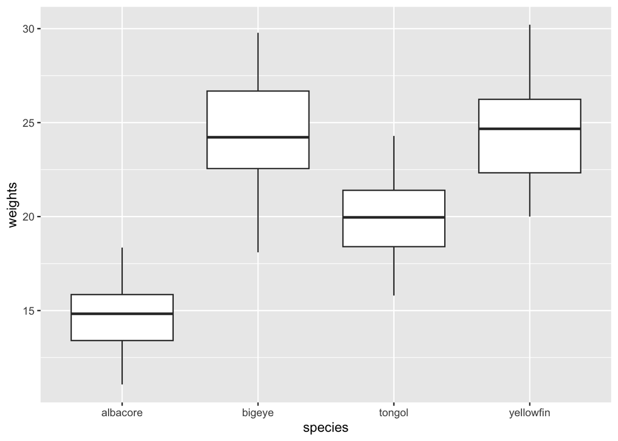

```r
#place code here.
ggplot(data = fish,
       aes(x = species, y = weights))+
    geom_boxplot()
```

Here’s a fun alternative to boxplots, something called a “violin plot”.

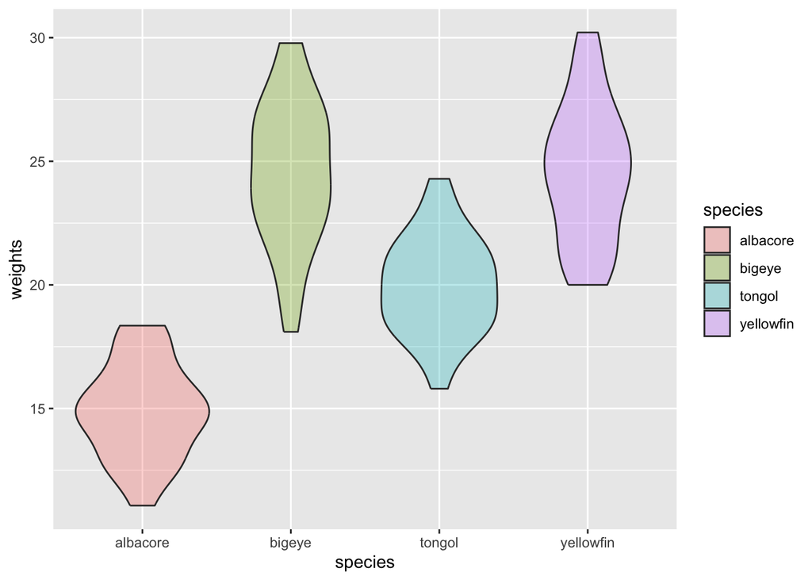

```r
fish %>%
    ggplot(data = .,
           aes(x = species,y = weights, fill = species))+
    geom_violin(alpha = .3)
```

The shape of the “violins” gives us a sense, like a histogram, where most of the data falls. For example, albacore tuna have more fish of weight 15 as indicated by the violin being quite wide there.

1. Pick two species of tuna, and compare a difference in their population mean weights *using a confidence interval.*
- *Remember to check you assumptions before running the test!*

*Show Work Below:*

```r
#place code here.
fish %>%
    filter(species %in% c("bigeye", "albacore")) -> fish1

fish1 %>% group_by(species)%>%
    summarise(stdev = sd(weights),
              sample_size = n())
```

| species | stdev | sample_size |
| --- | --- | --- |
| albacore | 1.916580 | 26 |
| bigeye | 2.871684 | 43 |

The standard deviations follow the three-fold rule, so we can assume equal variation. The sample size for albacore is below 30, but fish weights are likely normal at the population level, so our t-test tweak will take care of the small sample size in this case.

```r
fish1 %>%
    t.test(weights ~ species, data = .,
           var.equal = T) %>% tidy() %>%
    select(estimate, conf.low, conf.high)
```

| estimate | conf.low | conf.high |
| --- | --- | --- |
| -9.609481 | -10.8776 | -8.341366 |

We can be 95% confident that the difference in the population mean weights (with albacore as group 1) falls between -10.88 and -8.34 pounds. Since the confidence interval is entirely negative, we have evidence to suggest that the albacore tuna have a smaller population mean weight. Specifically, the population mean weight for albacore tuna could be as much as 10.8 pounds smaller, or as little as 8.34 pounds smaller.

2. Pick two *new* species to compare, again explore using a confidence interval.

*Show Work Below:*

Let’s compare bigeye tuna to yellow-fin.

```r
#place code here.
fish %>%
    filter(species %in% c("bigeye", "yellowfin")) -> fish2

fish2 %>% group_by(species)%>%
    summarise(stdev = sd(weights),
              sample_size = n())
```

| species | stdev | sample_size |
| --- | --- | --- |
| bigeye | 2.871684 | 43 |
| yellowfin | 2.781986 | 33 |

The sample sizes for each species are both above 30, so we have large enough samples to trust our confidence interval. Moreover, the standard deviations on the samples are very close, indicating that we can assume equal variances.

Let’s run our analysis:

```r
fish2 %>%
    t.test(weights ~ species, data = .,
           var.equal = T) %>% tidy() %>%
    select(estimate, conf.low, conf.high)
```

| estimate | conf.low | conf.high |
| --- | --- | --- |
| -0.0368358 | -1.34333 | 1.269658 |

We can be 95% confident that the difference in the population mean weights (bigeye as group 1) falls between -1.34 and 1.27 poudns. Since this interval contains zero, the evidence presented by the data suggests it is possible for the population mean weights for these two species to be equal.